# Demo: Control-flow

NIHES BST02

Nicole Erler, Department of Biostatistics, Erasmus Medical Center

15 February 2021

## `ifelse()` vs `if() ... else ...`

Let’s see what happens when we use the `ifelse()` example from the slides with `if() ... else ...`

```r
x <- rnorm(10)
ifelse(x < 0, "<0", ">0")
```

```
##  [1] "<0" "<0" "<0" ">0" ">0" "<0" "<0" "<0" ">0" "<0"
```

```r
if (x < 0) {
  "<0"
} else {
  ">0"
}
```

```
## [1] "<0"
```

The problem here is that `if()` expects an expression that either returns `TRUE` or `FALSE`, but we gave it a vector:

```r
x < 0
```

```
##  [1]  TRUE  TRUE  TRUE FALSE FALSE  TRUE  TRUE  TRUE FALSE  TRUE
```

In this case, only the first element of this vector is used.

On the other hand, the `if () ... else ...` example from the slides works in both cases:

```r
if (length(x) > 5) {
  mean(x)
} else {
  x
}
```

```
## [1] -0.008715537
```

```r
ifelse(length(x) > 5, mean(x), x)
```

```
## [1] -0.008715537
```

But for other cases it may not do what we expect it to do:

```r
x <- list(a = 5, b = rnorm(7), c = rnorm(4))
x
```

```
## $a
## [1] 5
##
## $b
## [1]  0.25331851 -0.02854676 -0.04287046  1.36860228 -0.22577099  1.51647060 -1.54875280
##
## $c
## [1] 0.5846137 0.1238542 0.2159416 0.3796395
```

```r
ifelse(length(x) > 5, mean(x), x)
```

```
## [[1]]
## [1] 5
```

Here, the “test” `length(x) > 5` results in `FALSE`, but because `ifelse()` expects a vector of “tests” (and only receives one “test”), it will only return the first element of `x`.

But `if() ... else ...` also does not work per element:

```r
if (length(x) > 5) {
  mean(x)
} else {
  x
}
```

```
## $a
## [1] 5
##
## $b
## [1]  0.25331851 -0.02854676 -0.04287046  1.36860228 -0.22577099  1.51647060 -1.54875280
##
## $c
## [1] 0.5846137 0.1238542 0.2159416 0.3796395
```

## `for()`-loop

We could solve the above issue using a `for()`-loop. This allows us to look at each element of `x` separately. Here, the function `seq_along()` comes in handy:

```r
seq_along(x)
```

```
## [1] 1 2 3
```

It produces a sequence with the same length as `x` has elements. Because we are using a loop, we need to add the `print()` function to see the printed output.

```r
for (i in seq_along(x)) {

  if (length(x[[i]]) > 5) {
    print(mean(x[[i]]))
  } else {
    print(x[[i]])
  }

}
```

```
## [1] 5
## [1] 0.1846358
## [1] 0.5846137 0.1238542 0.2159416 0.3796395
```

We could also “collect” the output in a new object:

```r
output <- list()

for (i in seq_along(x)) {

  output[[i]] <- if (length(x[[i]]) > 5) {
    mean(x[[i]])
  } else {
    x[[i]]
  }

}

output
```

```
## [[1]]
## [1] 5
##
## [[2]]
## [1] 0.1846358
##
## [[3]]
## [1] 0.5846137 0.1238542 0.2159416 0.3796395
```

## An example with `while()`

`while()` requires a `condition` that at some point is `FALSE` for the loop to stop.

The following would run forever (stop it by pressing “Esc” when in the Console):

```r
i <- 0
while (i < 5) {
  print(i)
}
```

This one here could also take very long. Instead of printing the output we save it in a vector that we can plot afterwards.

```r
x <- 0
xvec <- c()

while (x < 5) {
  x <- x + rnorm(1, 0, 1)
  xvec <- c(xvec, x)
}

length(xvec)
```

```
## [1] 37
```

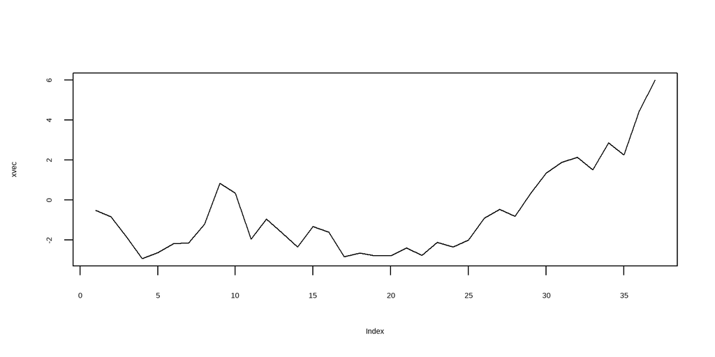

```r
plot(xvec, type = 'l')
```

We could extend the syntax from above by adding a counter

```r
x <- i <- 0
xvec <- c()

while (x < 5 & i < 25) {
  x <- x + rnorm(1, 0, 1)
  xvec <- c(xvec, x)
  i <- i + 1
}
xvec
```

```
##  [1] -0.2357004 -1.2621213 -1.9725278 -1.7156441 -1.9623360 -2.3098786 -3.2614972 -3.3065249 -4.0914294 -5.7593713
## [11] -6.1395978 -5.2206012 -5.7959482 -5.1879838 -6.8058665 -6.8614285 -6.3420213 -6.0408679 -5.9351918 -6.5758978
## [21] -7.4256021 -8.4497309 -8.3320843 -9.2795589 -9.7701164
```

Now we will get a maximum of 25 iterations. The loop stops as soon as `x` is larger than or equal to 5, or if 25 iterations are reached.